# exercise-12

Jamie Wiener

2024-04-13

```r
library(tidyverse)
library(dplyr)
library(mosaic)
library(readr)
library(skimr)
library(ggplot2)
library(MASS)
library(AICcmodavg)
library(MuMIn)
```

```r
#Read in Mammal Life Histories dataset
f <- "https://raw.githubusercontent.com/difiore/ada-2024-datasets/main/Mammal_lifehistories_v2.txt"
d <- read_tsv(f, col_names = TRUE)
```

## Exploratory data analysis

In the dataset, d:

- the following variables (total = 10) are numeric:

```r
skim <- skim(d)

skim_num <- skim |> filter(skim_type == "numeric")
print(skim_num$skim_variable) #Which variables are numeric
```

```
##  [1] "mass(g)"       "gestation(mo)" "newborn(g)"    "weaning(mo)"
##  [5] "wean mass(g)"  "AFR(mo)"       "max. life(mo)" "litter size"
##  [9] "litters/year"  "refs"
```

```r
print(length(skim_num$skim_variable)) #How many variables are numeric
```

```
## [1] 10
```

- the following variables (total = 4) are categorical:

```r
skim_char <- skim |> filter(skim_type == "character")
print(skim_char$skim_variable) #Which are character variables
```

```
## [1] "order"   "family"  "Genus"   "species"
```

```r
print(length(skim_char$skim_variable)) #How many are character variables
```

```
## [1] 4
```

## Step 1

Replace all values of -999 (the authors’ code for missing data) with NA.

```r
#Replace -999s with NA
d <- d |> mutate(
  `mass(g)` = na_if(`mass(g)`, -999),
  `gestation(mo)` = na_if(`gestation(mo)`, -999),
  `newborn(g)` = na_if(`newborn(g)`, -999),
  `weaning(mo)`= na_if(`weaning(mo)`, -999),
  `wean mass(g)` = na_if(`wean mass(g)`, -999),
  `AFR(mo)` = na_if(`AFR(mo)`, -999),
  `max. life(mo)` = na_if(`max. life(mo)`, -999),
  `litter size` = na_if(`litter size`, -999),
  `litters/year` = na_if(`litters/year`, -999))
```

## Step 2

Drop the variables litter size and refs.

```r
d <- d |>  dplyr::select(-`litter size`, -`refs`)
```

## Step 3

Log transform all of the other numeric variables.

```r
d <- d |> mutate(across(where(is.numeric), log))
```

## Step 4

Regress the (now log transformed) age [gestation(mo), weaning(mo), AFR(mo) (age at first reproduction), and max. life(mo) (maximum lifespan)] and mass [newborn(g) and wean mass(g)] variables on (now log transformed) overall body mass(g) and add the residuals to the dataframe as new variables (relGest, relWean, relAFR, relLife, relNewbornMass, and relWeaningMass).

Then, add the residuals to the dataframe as new variables (relGest, relWean, relAFR, relLife, relNewbornMass, and relWeaningMass).

```r
#Regressing gestation(mo) on overall body mass(g)

m1 <- lm(`gestation(mo)` ~ `mass(g)`, data = d, na.action = na.exclude)
(summary(m1))
```

```
##
## Call:
## lm(formula = `gestation(mo)` ~ `mass(g)`, data = d, na.action = na.exclude)
##
## Residuals:
##      Min       1Q   Median       3Q      Max
## -1.39347 -0.33659 -0.01871  0.32841  1.56568
##
## Coefficients:
##              Estimate Std. Error t value Pr(>|t|)
## (Intercept) -0.939838   0.037045  -25.37   <2e-16 ***
## `mass(g)`    0.249980   0.004561   54.80   <2e-16 ***
## ---
## Signif. codes:  0 '***' 0.001 '**' 0.01 '*' 0.05 '.' 0.1 ' ' 1
##
## Residual standard error: 0.4789 on 989 degrees of freedom
##   (449 observations deleted due to missingness)
## Multiple R-squared:  0.7523, Adjusted R-squared:  0.752
## F-statistic:  3004 on 1 and 989 DF,  p-value: < 2.2e-16
```

```r
#Adding residuals to dataframe (d) as a new variable (relGest)

d$relGest <- residuals(m1)
```

```r
#Regressing weaning(mo) on overall body mass(g)

m2 <- lm(`weaning(mo)` ~ `mass(g)`, data = d, na.action = na.exclude)
(summary(m2))
```

```
##
## Call:
## lm(formula = `weaning(mo)` ~ `mass(g)`, data = d, na.action = na.exclude)
##
## Residuals:
##      Min       1Q   Median       3Q      Max
## -3.10539 -0.38046 -0.05381  0.32894  2.30211
##
## Coefficients:
##              Estimate Std. Error t value Pr(>|t|)
## (Intercept) -0.870379   0.059633  -14.60   <2e-16 ***
## `mass(g)`    0.226004   0.007438   30.39   <2e-16 ***
## ---
## Signif. codes:  0 '***' 0.001 '**' 0.01 '*' 0.05 '.' 0.1 ' ' 1
##
## Residual standard error: 0.7097 on 800 degrees of freedom
##   (638 observations deleted due to missingness)
## Multiple R-squared:  0.5358, Adjusted R-squared:  0.5352
## F-statistic: 923.3 on 1 and 800 DF,  p-value: < 2.2e-16
```

```r
#Adding residuals to dataframe (d) as a new variable (relWean)

d$relWean <- residuals(m2)
```

```r
#Regressing AFR(mo) on overall body mass(g)

m3 <- lm(`AFR(mo)` ~ `mass(g)`, data = d, na.action = na.exclude)
(summary(m3))
```

```
##
## Call:
## lm(formula = `AFR(mo)` ~ `mass(g)`, data = d, na.action = na.exclude)
##
## Residuals:
##      Min       1Q   Median       3Q      Max
## -2.09019 -0.55017 -0.08892  0.59805  1.88853
##
## Coefficients:
##             Estimate Std. Error t value Pr(>|t|)
## (Intercept) 0.393101   0.065898   5.965 3.64e-09 ***
## `mass(g)`   0.276257   0.007984  34.601  < 2e-16 ***
## ---
## Signif. codes:  0 '***' 0.001 '**' 0.01 '*' 0.05 '.' 0.1 ' ' 1
##
## Residual standard error: 0.7668 on 815 degrees of freedom
##   (623 observations deleted due to missingness)
## Multiple R-squared:  0.595,  Adjusted R-squared:  0.5945
## F-statistic:  1197 on 1 and 815 DF,  p-value: < 2.2e-16
```

```r
#Adding residuals to dataframe (d) as a new variable (relAFR)

d$relAFR <- residuals(m3)
```

```r
#Regressing max.life(mo) on overall body mass(g)

m4 <- lm(`max. life(mo)` ~ `mass(g)`, data = d, na.action = na.exclude)
(summary(m4))
```

```
##
## Call:
## lm(formula = `max. life(mo)` ~ `mass(g)`, data = d, na.action = na.exclude)
##
## Residuals:
##     Min      1Q  Median      3Q     Max
## -1.4969 -0.3053 -0.0303  0.3465  1.4944
##
## Coefficients:
##             Estimate Std. Error t value Pr(>|t|)
## (Intercept) 3.277746   0.053566   61.19   <2e-16 ***
## `mass(g)`   0.218721   0.006063   36.08   <2e-16 ***
## ---
## Signif. codes:  0 '***' 0.001 '**' 0.01 '*' 0.05 '.' 0.1 ' ' 1
##
## Residual standard error: 0.5135 on 590 degrees of freedom
##   (848 observations deleted due to missingness)
## Multiple R-squared:  0.6881, Adjusted R-squared:  0.6875
## F-statistic:  1301 on 1 and 590 DF,  p-value: < 2.2e-16
```

```r
#Adding residuals to dataframe (d) as a new variable (relLife)

d$relLife <- residuals(m4)
```

```r
#Regressing newborn(g) on overall body mass(g)

m5 <- lm(`newborn(g)` ~ `mass(g)`, data = d, na.action = na.exclude)
(summary(m5))
```

```
##
## Call:
## lm(formula = `newborn(g)` ~ `mass(g)`, data = d, na.action = na.exclude)
##
## Residuals:
##     Min      1Q  Median      3Q     Max
## -3.7195 -0.4223  0.0945  0.4994  2.1097
##
## Coefficients:
##              Estimate Std. Error t value Pr(>|t|)
## (Intercept) -2.623637   0.062441  -42.02   <2e-16 ***
## `mass(g)`    0.949620   0.007812  121.57   <2e-16 ***
## ---
## Signif. codes:  0 '***' 0.001 '**' 0.01 '*' 0.05 '.' 0.1 ' ' 1
##
## Residual standard error: 0.7266 on 814 degrees of freedom
##   (624 observations deleted due to missingness)
## Multiple R-squared:  0.9478, Adjusted R-squared:  0.9477
## F-statistic: 1.478e+04 on 1 and 814 DF,  p-value: < 2.2e-16
```

```r
#Adding residuals to dataframe (d) as a new variable (relNewbornMass)

d$relNewbornMass <- residuals(m5)
```

```r
#Regressing wean mass(g) on overall body mass(g)

m6 <- lm(`wean mass(g)` ~ `mass(g)`, data = d, na.action = na.exclude)
(summary(m6))
```

```
##
## Call:
## lm(formula = `wean mass(g)` ~ `mass(g)`, data = d, na.action = na.exclude)
##
## Residuals:
##      Min       1Q   Median       3Q      Max
## -1.94111 -0.30781  0.01617  0.34331  1.29245
##
## Coefficients:
##              Estimate Std. Error t value Pr(>|t|)
## (Intercept) -0.722663   0.061049  -11.84   <2e-16 ***
## `mass(g)`    0.931989   0.008234  113.19   <2e-16 ***
## ---
## Signif. codes:  0 '***' 0.001 '**' 0.01 '*' 0.05 '.' 0.1 ' ' 1
##
## Residual standard error: 0.5191 on 394 degrees of freedom
##   (1044 observations deleted due to missingness)
## Multiple R-squared:  0.9702, Adjusted R-squared:  0.9701
## F-statistic: 1.281e+04 on 1 and 394 DF,  p-value: < 2.2e-16
```

```r
#Adding residuals to dataframe (d) as a new variable (relWeaningMass)

d$relWeaningMass <- residuals(m6)
```

## Step 5

Plot residuals of max lifespan (relLife) in relation to Order.

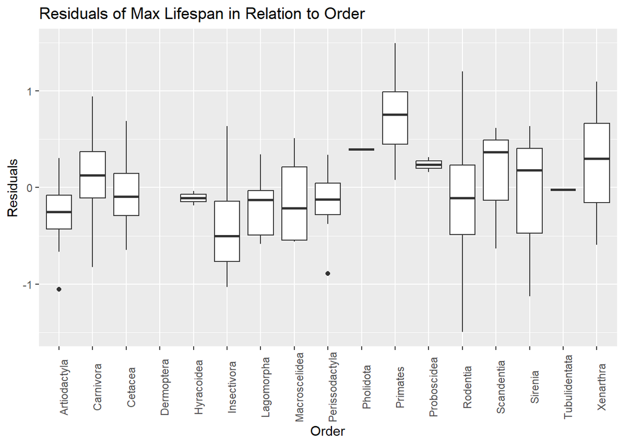

```r
p1 <- ggplot(data = d, aes(x = order, y = relLife)) +
  geom_boxplot() +
  theme(axis.text.x = element_text(angle = 90)) +
  ggtitle("Residuals of Max Lifespan in Relation to Order ") +
  ylab("Residuals") +
  xlab("Order")
(p1)
```

Order Primates has the highest residual lifespan

Plot residuals of newborn mass (relNewbornMass) in relation to Order.

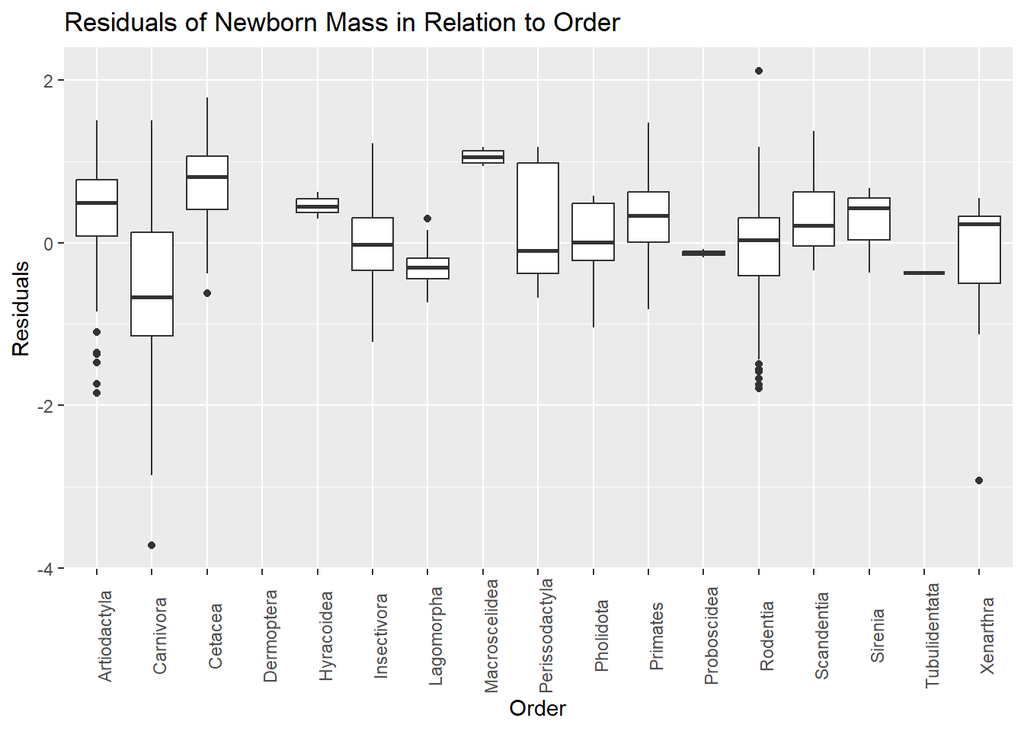

```r
p2 <- ggplot(data = d, aes(x = order, y = relNewbornMass)) +
  geom_boxplot() +
  theme(axis.text.x = element_text(angle = 90)) +
  ggtitle("Residuals of Newborn Mass in Relation to Order ") +
  ylab("Residuals") +
  xlab("Order")
(p2)
```

Order Macroscelidea has the highest residual newborn mass.

Plot residuals of weaning mass (relWeaningMass) in relation to Order.

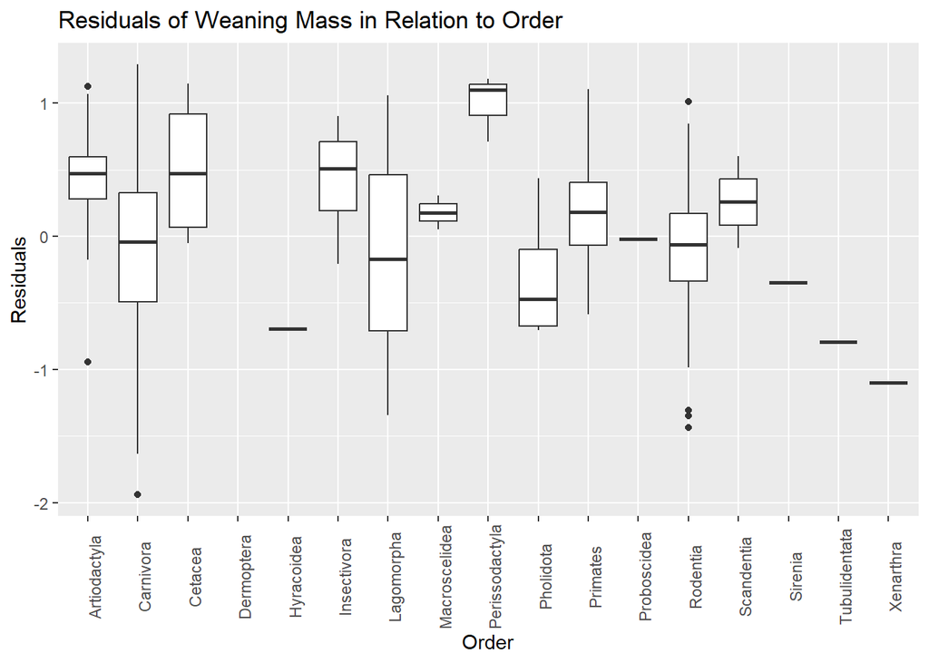

```r
p3 <- ggplot(data = d, aes(x = order, y = relWeaningMass)) +
  geom_boxplot() +
  theme(axis.text.x = element_text(angle = 90)) +
  ggtitle("Residuals of Weaning Mass in Relation to Order ") +
  ylab("Residuals") +
  xlab("Order")
(p3)
```

Order Perissodactyla has the highest residual weaning mass.

## Step 6

Run models and a model selection process to evaluate what variables best predict max. life(mo) from the set of the following predictors: gestation(mo), newborn(g), weaning(mo), wean mass(g), litters/year, and overall body mass(g).

```r
d_new <- d |> drop_na(`max. life(mo)`,`AFR(mo)`,`gestation(mo)`,`newborn(g)`,`weaning(mo)`,`wean mass(g)`,`litters/year`,`mass(g)`)

m_full1 <- lm(data = d_new, `max. life(mo)` ~ `gestation(mo)` + `newborn(g)` + `weaning(mo)` + `wean mass(g)` + `litters/year` + `mass(g)`)

s1 <- stepAIC(m_full1, scope = .~., direction = "both", trace = TRUE)
```

```
## Start:  AIC=-327.43
## `max. life(mo)` ~ `gestation(mo)` + `newborn(g)` + `weaning(mo)` +
##     `wean mass(g)` + `litters/year` + `mass(g)`
##
##                   Df Sum of Sq    RSS     AIC
## - `wean mass(g)`   1   0.02286 39.293 -329.31
## - `newborn(g)`     1   0.23054 39.500 -328.22
## <none>                         39.270 -327.43
## - `mass(g)`        1   0.72550 39.995 -325.66
## - `weaning(mo)`    1   1.09732 40.367 -323.75
## - `litters/year`   1   1.72842 40.998 -320.56
## - `gestation(mo)`  1   2.71500 41.985 -315.66
##
## Step:  AIC=-329.31
## `max. life(mo)` ~ `gestation(mo)` + `newborn(g)` + `weaning(mo)` +
##     `litters/year` + `mass(g)`
##
##                   Df Sum of Sq    RSS     AIC
## - `newborn(g)`     1   0.21387 39.507 -330.19
## <none>                         39.293 -329.31
## + `wean mass(g)`   1   0.02286 39.270 -327.43
## - `weaning(mo)`    1   1.15324 40.446 -325.35
## - `mass(g)`        1   1.63907 40.932 -322.89
## - `litters/year`   1   1.77294 41.066 -322.22
## - `gestation(mo)`  1   2.70723 42.000 -317.58
##
## Step:  AIC=-330.19
## `max. life(mo)` ~ `gestation(mo)` + `weaning(mo)` + `litters/year` +
##     `mass(g)`
##
##                   Df Sum of Sq    RSS     AIC
## <none>                         39.507 -330.19
## + `newborn(g)`     1    0.2139 39.293 -329.31
## + `wean mass(g)`   1    0.0062 39.500 -328.22
## - `weaning(mo)`    1    1.4531 40.960 -324.75
## - `litters/year`   1    2.1006 41.607 -321.52
## - `gestation(mo)`  1    3.2623 42.769 -315.85
## - `mass(g)`        1    3.6976 43.204 -313.76
```

```r
(s1)
```

```
##
## Call:
## lm(formula = `max. life(mo)` ~ `gestation(mo)` + `weaning(mo)` +
##     `litters/year` + `mass(g)`, data = d_new)
##
## Coefficients:
##     (Intercept)  `gestation(mo)`    `weaning(mo)`   `litters/year`
##         4.03241          0.29528          0.14159         -0.25252
##       `mass(g)`
##         0.08226
```

Based on AIC values calculated in the above step-wise model selection using {MASS}, the variables that best predict max. life(mo) are gestation(mo), weaning(mo), litters/year, and mass(g).

```r
# I am not sure if there is a more efficient way to do this rather than doing a model selection process by hand?

#Backward selection

ma <- lm(`max. life(mo)` ~ `gestation(mo)` + `newborn(g)` + `weaning(mo)` +
    `wean mass(g)` + `litters/year` + `mass(g)`, data = d_new)

drop1(ma, test = "F")
```

```
## Single term deletions
##
## Model:
## `max. life(mo)` ~ `gestation(mo)` + `newborn(g)` + `weaning(mo)` +
##     `wean mass(g)` + `litters/year` + `mass(g)`
##                 Df Sum of Sq    RSS     AIC F value    Pr(>F)
## <none>                       39.270 -327.43
## `gestation(mo)`  1   2.71500 41.985 -315.66 13.7583 0.0002696 ***
## `newborn(g)`     1   0.23054 39.500 -328.22  1.1682 0.2810706
## `weaning(mo)`    1   1.09732 40.367 -323.75  5.5606 0.0193385 *
## `wean mass(g)`   1   0.02286 39.293 -329.31  0.1158 0.7339527
## `litters/year`   1   1.72842 40.998 -320.56  8.7588 0.0034551 **
## `mass(g)`        1   0.72550 39.995 -325.66  3.6765 0.0566178 .
## ---
## Signif. codes:  0 '***' 0.001 '**' 0.01 '*' 0.05 '.' 0.1 ' ' 1
```

```r
mb <- update(ma, . ~ . - `weaning(mo)`)

drop1(mb, test = "F")
```

```
## Single term deletions
##
## Model:
## `max. life(mo)` ~ `gestation(mo)` + `newborn(g)` + `wean mass(g)` +
##     `litters/year` + `mass(g)`
##                 Df Sum of Sq    RSS     AIC F value    Pr(>F)
## <none>                       40.367 -323.75
## `gestation(mo)`  1    6.0713 46.438 -296.89 30.0802 1.243e-07 ***
## `newborn(g)`     1    0.5877 40.955 -322.77  2.9118   0.08949 .
## `wean mass(g)`   1    0.0788 40.446 -325.35  0.3903   0.53285
## `litters/year`   1    4.2013 44.569 -305.35 20.8155 8.812e-06 ***
## `mass(g)`        1    0.7267 41.094 -322.08  3.6003   0.05921 .
## ---
## Signif. codes:  0 '***' 0.001 '**' 0.01 '*' 0.05 '.' 0.1 ' ' 1
```

```r
mc <- update(mb, . ~ . - `wean mass(g)`)

drop1(mc, test = "F")
```

```
## Single term deletions
##
## Model:
## `max. life(mo)` ~ `gestation(mo)` + `newborn(g)` + `litters/year` +
##     `mass(g)`
##                 Df Sum of Sq    RSS     AIC F value    Pr(>F)
## <none>                       40.446 -325.35
## `gestation(mo)`  1    6.1521 46.598 -298.18 30.5735 9.917e-08 ***
## `newborn(g)`     1    0.5138 40.960 -324.75  2.5533  0.111634
## `litters/year`   1    4.4995 44.946 -305.62 22.3609 4.247e-06 ***
## `mass(g)`        1    1.9825 42.428 -317.49  9.8520  0.001952 **
## ---
## Signif. codes:  0 '***' 0.001 '**' 0.01 '*' 0.05 '.' 0.1 ' ' 1
```

```r
md <- update(mc, . ~ . - `newborn(g)`)

drop1(md, test = "F")
```

```
## Single term deletions
##
## Model:
## `max. life(mo)` ~ `gestation(mo)` + `litters/year` + `mass(g)`
##                 Df Sum of Sq    RSS     AIC F value    Pr(>F)
## <none>                       40.960 -324.75
## `gestation(mo)`  1    7.2054 48.165 -293.37  35.535 1.101e-08 ***
## `litters/year`   1    6.4504 47.410 -296.62  31.811 5.680e-08 ***
## `mass(g)`        1    2.9613 43.921 -312.37  14.604 0.0001765 ***
## ---
## Signif. codes:  0 '***' 0.001 '**' 0.01 '*' 0.05 '.' 0.1 ' ' 1
```

```r
me <- update(md, . ~ . - `mass(g)`)

drop1(me, test = "F")
```

```
## Single term deletions
##
## Model:
## `max. life(mo)` ~ `gestation(mo)` + `litters/year`
##                 Df Sum of Sq    RSS     AIC F value    Pr(>F)
## <none>                       43.921 -312.37
## `gestation(mo)`  1   30.3510 74.272 -206.15 140.280 < 2.2e-16 ***
## `litters/year`   1    9.6629 53.584 -273.40  44.661 2.212e-10 ***
## ---
## Signif. codes:  0 '***' 0.001 '**' 0.01 '*' 0.05 '.' 0.1 ' ' 1
```

```r
mf <- update(me, . ~ . - `litters/year`)

drop1(mf, test = "F")
```

```
## Single term deletions
##
## Model:
## `max. life(mo)` ~ `gestation(mo)`
##                 Df Sum of Sq     RSS      AIC F value    Pr(>F)
## <none>                        53.584 -273.405
## `gestation(mo)`  1    116.37 169.953  -37.625  443.03 < 2.2e-16 ***
## ---
## Signif. codes:  0 '***' 0.001 '**' 0.01 '*' 0.05 '.' 0.1 ' ' 1
```

```r
mg <- update(mf, . ~ . - `gestation(mo)`)

(aictab(list(ma, mb, mc,md,me,mf,mg), c("ma", "mb", "mc","md","me","mf","mg")))
```

```
##
## Model selection based on AICc:
##
##    K   AICc Delta_AICc AICcWt Cum.Wt      LL
## ma 8 259.91       0.00   0.52   0.52 -121.59
## mc 6 261.68       1.77   0.22   0.74 -124.63
## md 5 262.15       2.25   0.17   0.91 -125.93
## mb 7 263.42       3.51   0.09   1.00 -124.43
## me 4 274.43      14.53   0.00   1.00 -133.12
## mf 3 313.32      53.41   0.00   1.00 -153.60
## mg 2 549.04     289.13   0.00   1.00 -272.49
```

The best model overall based on AICc is:

max. life(mo) ~ gestation(mo) + newborn(g) + weaning(mo) + wean mass(g) + litters/year + mass(g)

4 models have a delta AICc of 4 or less. Gestation(mo), litters/year, and mass(g) appear in all “top” models.

Calculate and plot the model-averaged coefficients and their CIs across this set of top models.

```r
#Calculating the model-averaged coefficients using {MuMIn}

global <- lm(`max. life(mo)` ~ `gestation(mo)` + `newborn(g)` + `weaning(mo)` +
    `wean mass(g)` + `litters/year` + `mass(g)`, data = d_new, na.action = "na.fail")

mods <- dredge(global, beta = "none", m.lim = c(0, 6))
```

```
## Fixed term is "(Intercept)"
```

```r
(mods.avg <- summary(model.avg(mods, subset = delta < 4, fit = TRUE))) #Looking at "top" models with delta AICc less than 4
```

```
##
## Call:
## model.avg(object = get.models(object = mods, subset = delta <
##     4))
##
## Component model call:
## lm(formula = `max. life(mo)` ~ <5 unique rhs>, data = d_new, na.action
##      = na.fail)
##
## Component models:
##        df  logLik   AICc delta weight
## 1236    6 -122.21 256.83  0.00   0.42
## 12346   7 -121.65 257.86  1.03   0.25
## 12356   7 -122.19 258.95  2.11   0.14
## 1256    6 -123.63 259.69  2.85   0.10
## 123456  8 -121.59 259.91  3.07   0.09
##
## Term codes:
## `gestation(mo)`  `litters/year`       `mass(g)`    `newborn(g)`  `wean mass(g)`
##               1               2               3               4               5
##   `weaning(mo)`
##               6
##
## Model-averaged coefficients:
## (full average)
##                 Estimate Std. Error Adjusted SE z value Pr(>|z|)
## (Intercept)      4.00291    0.16134     0.16215  24.687  < 2e-16 ***
## `gestation(mo)`  0.31844    0.08975     0.09022   3.530 0.000416 ***
## `litters/year`  -0.24853    0.07848     0.07895   3.148 0.001645 **
## `mass(g)`        0.08746    0.04908     0.04925   1.776 0.075726 .
## `weaning(mo)`    0.13659    0.05294     0.05326   2.565 0.010332 *
## `newborn(g)`    -0.01920    0.04131     0.04146   0.463 0.643204
## `wean mass(g)`   0.00911    0.04176     0.04191   0.217 0.827903
##
## (conditional average)
##                 Estimate Std. Error Adjusted SE z value Pr(>|z|)
## (Intercept)      4.00291    0.16134     0.16215  24.687  < 2e-16 ***
## `gestation(mo)`  0.31844    0.08975     0.09022   3.530 0.000416 ***
## `litters/year`  -0.24853    0.07848     0.07895   3.148 0.001645 **
## `mass(g)`        0.09717    0.04164     0.04185   2.322 0.020236 *
## `weaning(mo)`    0.13659    0.05294     0.05326   2.565 0.010332 *
## `newborn(g)`    -0.05666    0.05398     0.05431   1.043 0.296810
## `wean mass(g)`   0.02724    0.06870     0.06898   0.395 0.692865
## ---
## Signif. codes:  0 '***' 0.001 '**' 0.01 '*' 0.05 '.' 0.1 ' ' 1
```

```r
#Calculating CIs for model-averaged coefficients

(confint(mods.avg))
```

```
##                       2.5 %      97.5 %
## (Intercept)      3.68511191  4.32071260
## `gestation(mo)`  0.14160671  0.49526367
## `litters/year`  -0.40327078 -0.09378398
## `mass(g)`        0.01514783  0.17918817
## `weaning(mo)`    0.03219892  0.24097775
## `newborn(g)`    -0.16309576  0.04978052
## `wean mass(g)`  -0.10794856  0.16243631
```

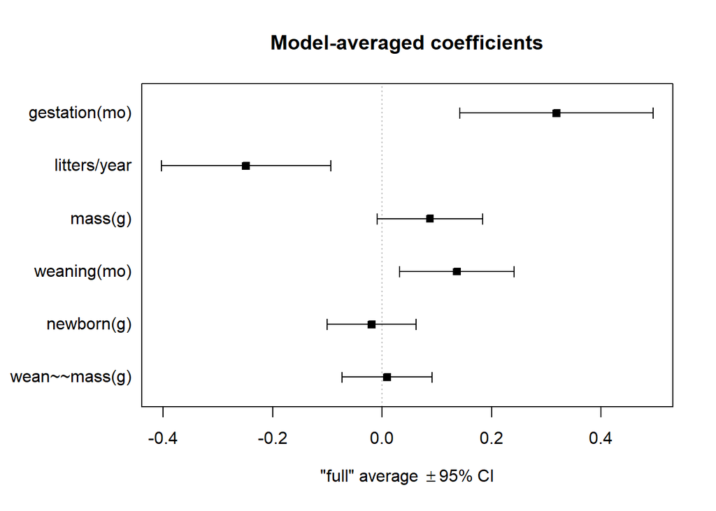

```
##                          px py          lx0 ly0         lx1 ly1
## `gestation(mo)`  0.31843519  6  0.141606708   6  0.49526367   6
## `litters/year`  -0.24852738  5 -0.403270783   5 -0.09378398   5
## `mass(g)`        0.08746290  4 -0.009057336   4  0.18398314   4
## `weaning(mo)`    0.13658833  3  0.032198921   3  0.24097775   3
## `newborn(g)`    -0.01920547  2 -0.100466619   2  0.06205567   2
## `wean mass(g)`   0.00911026  1 -0.073026096   1  0.09124662   1
```

```r
#Plotting the model-averaged coefficients and their CIs

(plot(mods.avg, full = TRUE, intercept = FALSE))
```

Run models and a model selection process to evaluate what variables best predict AFR(mo) from the set of the following predictors: gestation(mo), newborn(g), weaning(mo), wean mass(g), litters/year, and overall body mass(g).

```r
m_full2 <- lm(data = d_new, `AFR(mo)` ~ `gestation(mo)` + `newborn(g)` + `weaning(mo)` + `wean mass(g)` + `litters/year` + `mass(g)`)

s2 <- stepAIC(m_full2, scope = .~., direction = "both", trace = TRUE)
```

```
## Start:  AIC=-261.8
## `AFR(mo)` ~ `gestation(mo)` + `newborn(g)` + `weaning(mo)` +
##     `wean mass(g)` + `litters/year` + `mass(g)`
##
##                   Df Sum of Sq    RSS     AIC
## - `newborn(g)`     1    0.0007 54.003 -263.80
## - `wean mass(g)`   1    0.0008 54.003 -263.80
## - `mass(g)`        1    0.0756 54.078 -263.51
## <none>                         54.003 -261.80
## - `weaning(mo)`    1    1.4058 55.408 -258.51
## - `gestation(mo)`  1    3.3496 57.352 -251.41
## - `litters/year`   1   15.8129 69.815 -210.90
##
## Step:  AIC=-263.8
## `AFR(mo)` ~ `gestation(mo)` + `weaning(mo)` + `wean mass(g)` +
##     `litters/year` + `mass(g)`
##
##                   Df Sum of Sq    RSS     AIC
## - `wean mass(g)`   1    0.0003 54.004 -265.80
## - `mass(g)`        1    0.0777 54.081 -265.50
## <none>                         54.003 -263.80
## + `newborn(g)`     1    0.0007 54.003 -261.80
## - `weaning(mo)`    1    1.5166 55.520 -260.09
## - `gestation(mo)`  1    5.2066 59.210 -246.84
## - `litters/year`   1   16.5887 70.592 -210.62
##
## Step:  AIC=-265.8
## `AFR(mo)` ~ `gestation(mo)` + `weaning(mo)` + `litters/year` +
##     `mass(g)`
##
##                   Df Sum of Sq    RSS     AIC
## <none>                         54.004 -265.80
## - `mass(g)`        1    0.7156 54.719 -265.09
## + `wean mass(g)`   1    0.0003 54.003 -263.80
## + `newborn(g)`     1    0.0002 54.003 -263.80
## - `weaning(mo)`    1    1.5170 55.521 -262.09
## - `gestation(mo)`  1    6.0758 60.079 -245.84
## - `litters/year`   1   16.5910 70.595 -212.61
```

```r
(s2)
```

```
##
## Call:
## lm(formula = `AFR(mo)` ~ `gestation(mo)` + `weaning(mo)` + `litters/year` +
##     `mass(g)`, data = d_new)
##
## Coefficients:
##     (Intercept)  `gestation(mo)`    `weaning(mo)`   `litters/year`
##         1.97319          0.40296          0.14467         -0.70968
##       `mass(g)`
##         0.03619
```

Based on AIC values calculated in the above step-wise model selection using {MASS}, the variables that best predict AFR(mo) are gestation(mo), weaning(mo), litters/year, and mass(g).

```r
#Backward selection

ma2 <- lm(`AFR(mo)` ~ `gestation(mo)` + `newborn(g)` + `weaning(mo)` +
    `wean mass(g)` + `litters/year` + `mass(g)`, data = d_new)

drop1(ma2, test = "F")
```

```
## Single term deletions
##
## Model:
## `AFR(mo)` ~ `gestation(mo)` + `newborn(g)` + `weaning(mo)` +
##     `wean mass(g)` + `litters/year` + `mass(g)`
##                 Df Sum of Sq    RSS     AIC F value    Pr(>F)
## <none>                       54.003 -261.80
## `gestation(mo)`  1    3.3496 57.352 -251.41 12.3435 0.0005477 ***
## `newborn(g)`     1    0.0007 54.003 -263.80  0.0026 0.9592209
## `weaning(mo)`    1    1.4058 55.408 -258.51  5.1804 0.0239074 *
## `wean mass(g)`   1    0.0008 54.003 -263.80  0.0030 0.9562779
## `litters/year`   1   15.8129 69.815 -210.90 58.2708 9.319e-13 ***
## `mass(g)`        1    0.0756 54.078 -263.51  0.2787 0.5981348
## ---
## Signif. codes:  0 '***' 0.001 '**' 0.01 '*' 0.05 '.' 0.1 ' ' 1
```

```r
mb2 <- update(ma2, . ~ . - `newborn(g)`)

drop1(mb2, test = "F")
```

```
## Single term deletions
##
## Model:
## `AFR(mo)` ~ `gestation(mo)` + `weaning(mo)` + `wean mass(g)` +
##     `litters/year` + `mass(g)`
##                 Df Sum of Sq    RSS     AIC F value    Pr(>F)
## <none>                       54.003 -263.80
## `gestation(mo)`  1    5.2066 59.210 -246.84 19.2826 1.825e-05 ***
## `weaning(mo)`    1    1.5166 55.520 -260.09  5.6168   0.01874 *
## `wean mass(g)`   1    0.0003 54.004 -265.80  0.0013   0.97182
## `litters/year`   1   16.5887 70.592 -210.62 61.4359 2.661e-13 ***
## `mass(g)`        1    0.0777 54.081 -265.50  0.2879   0.59217
## ---
## Signif. codes:  0 '***' 0.001 '**' 0.01 '*' 0.05 '.' 0.1 ' ' 1
```

```r
mc2 <- update(mb2, . ~ . - `wean mass(g)`)

drop1(mc2, test = "F")
```

```
## Single term deletions
##
## Model:
## `AFR(mo)` ~ `gestation(mo)` + `weaning(mo)` + `litters/year` +
##     `mass(g)`
##                 Df Sum of Sq    RSS     AIC F value    Pr(>F)
## <none>                       54.004 -265.80
## `gestation(mo)`  1    6.0758 60.079 -245.84 22.6139 3.773e-06 ***
## `weaning(mo)`    1    1.5170 55.521 -262.09  5.6464   0.01843 *
## `litters/year`   1   16.5910 70.595 -212.61 61.7514 2.315e-13 ***
## `mass(g)`        1    0.7156 54.719 -265.09  2.6634   0.10425
## ---
## Signif. codes:  0 '***' 0.001 '**' 0.01 '*' 0.05 '.' 0.1 ' ' 1
```

```r
md2 <- update(mc2, . ~ . - `mass(g)`)

drop1(md2, test = "F")
```

```
## Single term deletions
##
## Model:
## `AFR(mo)` ~ `gestation(mo)` + `weaning(mo)` + `litters/year`
##                 Df Sum of Sq    RSS     AIC F value    Pr(>F)
## <none>                       54.719 -265.09
## `gestation(mo)`  1   18.5320 73.251 -207.00 68.4122 1.766e-14 ***
## `weaning(mo)`    1    1.1828 55.902 -262.68  4.3664   0.03791 *
## `litters/year`   1   21.1373 75.856 -199.80 78.0301 4.939e-16 ***
## ---
## Signif. codes:  0 '***' 0.001 '**' 0.01 '*' 0.05 '.' 0.1 ' ' 1
```

```r
me2 <- update(md2, . ~ . - `weaning(mo)`)

drop1(me2, test = "F")
```

```
## Single term deletions
##
## Model:
## `AFR(mo)` ~ `gestation(mo)` + `litters/year`
##                 Df Sum of Sq    RSS     AIC F value    Pr(>F)
## <none>                       55.902 -262.68
## `gestation(mo)`  1    30.045 85.947 -176.07  109.10 < 2.2e-16 ***
## `litters/year`   1    37.079 92.981 -159.87  134.65 < 2.2e-16 ***
## ---
## Signif. codes:  0 '***' 0.001 '**' 0.01 '*' 0.05 '.' 0.1 ' ' 1
```

```r
mf2 <- update(me2, . ~ . - `gestation(mo)`)

drop1(mf2, test = "F")
```

```
## Single term deletions
##
## Model:
## `AFR(mo)` ~ `litters/year`
##                Df Sum of Sq     RSS      AIC F value    Pr(>F)
## <none>                       85.947 -176.074
## `litters/year`  1    194.21 280.160   65.342  460.97 < 2.2e-16 ***
## ---
## Signif. codes:  0 '***' 0.001 '**' 0.01 '*' 0.05 '.' 0.1 ' ' 1
```

```r
mg2 <- update(mf2, . ~ . - `litters/year`)

(aictab(list(ma2, mb2, mc2,md2,me2,mf2,mg2), c("ma2", "mb2", "mc2","md2","me2","mf2","mg2")))
```

```
##
## Model selection based on AICc:
##
##     K   AICc Delta_AICc AICcWt Cum.Wt      LL
## mc2 6 321.23       0.00   0.41   0.41 -154.40
## md2 5 321.82       0.59   0.31   0.72 -155.76
## mb2 7 323.37       2.14   0.14   0.86 -154.40
## me2 4 324.12       2.89   0.10   0.95 -157.96
## ma2 8 325.53       4.30   0.05   1.00 -154.40
## mf2 3 410.65      89.42   0.00   1.00 -202.26
## mg2 2 652.00     330.78   0.00   1.00 -323.97
```

The best model overall based on AICc is:

AFR(mo) ~ gestation(mo) + weaning(mo) + litters/year + mass(g)

4 models have a delta AICc of 4 or less. Gestation(mo) and litters/year appear in all “top” models.

Calculate and plot the model-averaged coefficients and their CIs across this set of top models.

```r
#Calculating the model-averaged coefficients using {MuMIn}

global2 <- lm(`AFR(mo)` ~ `gestation(mo)` + `newborn(g)` + `weaning(mo)` +
    `wean mass(g)` + `litters/year` + `mass(g)`, data = d_new, na.action = "na.fail")

mods2 <- dredge(global2, beta = "none", m.lim = c(0, 6))
```

```
## Fixed term is "(Intercept)"
```

```r
(mods.avg2 <- summary(model.avg(mods2, subset = delta < 4, fit = TRUE))) #Looking at "top" models with delta AICc less than 4
```

```
##
## Call:
## model.avg(object = get.models(object = mods2, subset = delta <
##     4))
##
## Component model call:
## lm(formula = `AFR(mo)` ~ <10 unique rhs>, data = d_new, na.action =
##      na.fail)
##
## Component models:
##       df  logLik   AICc delta weight
## 1236   6 -154.40 321.23  0.00   0.20
## 1256   6 -154.55 321.52  0.30   0.18
## 126    5 -155.76 321.82  0.59   0.15
## 1246   6 -154.70 321.82  0.59   0.15
## 12356  7 -154.40 323.37  2.14   0.07
## 12346  7 -154.40 323.37  2.14   0.07
## 12456  7 -154.54 323.65  2.43   0.06
## 12     4 -157.96 324.12  2.89   0.05
## 123    5 -157.26 324.81  3.58   0.03
## 125    5 -157.32 324.94  3.71   0.03
##
## Term codes:
## `gestation(mo)`  `litters/year`       `mass(g)`    `newborn(g)`  `wean mass(g)`
##               1               2               3               4               5
##   `weaning(mo)`
##               6
##
## Model-averaged coefficients:
## (full average)
##                  Estimate Std. Error Adjusted SE z value Pr(>|z|)
## (Intercept)      2.059308   0.164411    0.165109  12.472  < 2e-16 ***
## `gestation(mo)`  0.424816   0.104323    0.104789   4.054 5.04e-05 ***
## `litters/year`  -0.736632   0.096521    0.097003   7.594  < 2e-16 ***
## `mass(g)`        0.013294   0.029383    0.029501   0.451    0.652
## `weaning(mo)`    0.125434   0.073485    0.073759   1.701    0.089 .
## `wean mass(g)`   0.009906   0.031169    0.031308   0.316    0.752
## `newborn(g)`     0.006295   0.028974    0.029108   0.216    0.829
##
## (conditional average)
##                 Estimate Std. Error Adjusted SE z value Pr(>|z|)
## (Intercept)      2.05931    0.16441     0.16511  12.472  < 2e-16 ***
## `gestation(mo)`  0.42482    0.10432     0.10479   4.054 5.04e-05 ***
## `litters/year`  -0.73663    0.09652     0.09700   7.594  < 2e-16 ***
## `mass(g)`        0.03511    0.03891     0.03915   0.897   0.3698
## `weaning(mo)`    0.14159    0.06171     0.06207   2.281   0.0225 *
## `wean mass(g)`   0.02921    0.04797     0.04823   0.606   0.5448
## `newborn(g)`     0.02227    0.05113     0.05140   0.433   0.6648
## ---
## Signif. codes:  0 '***' 0.001 '**' 0.01 '*' 0.05 '.' 0.1 ' ' 1
```

```r
#Calculating CIs for model-averaged coefficients

(confint(mods.avg2))
```

```
##                       2.5 %     97.5 %
## (Intercept)      1.73570076  2.3829161
## `gestation(mo)`  0.21943208  0.6301994
## `litters/year`  -0.92675475 -0.5465098
## `mass(g)`       -0.04161694  0.1118418
## `weaning(mo)`    0.01992847  0.2632574
## `wean mass(g)`  -0.06532930  0.1237398
## `newborn(g)`    -0.07846591  0.1230037
```

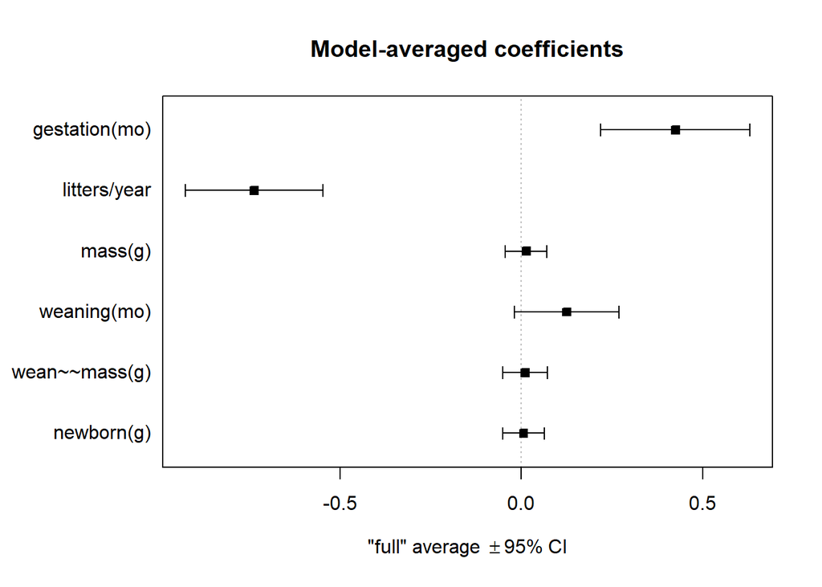

```
##                           px py         lx0 ly0         lx1 ly1
## `gestation(mo)`  0.424815719  6  0.21943208   6  0.63019936   6
## `litters/year`  -0.736632281  5 -0.92675475   5 -0.54650981   5
## `mass(g)`        0.013293763  4 -0.04452686   4  0.07111438   4
## `weaning(mo)`    0.125434007  3 -0.01913137   3  0.26999938   3
## `wean mass(g)`   0.009905543  2 -0.05145792   2  0.07126901   2
## `newborn(g)`     0.006295123  1 -0.05075616   1  0.06334641   1
```

```r
#Plotting the model-averaged coefficients and their CIs

(plot(mods.avg2, full = TRUE, intercept = FALSE))
```